# Cross-Seed Invariance Analysis

### 4.0 Grid Cadence & Window Scale Analysis

Understanding the relationship between capture cadence, event windows, and suppression radius.

```python
# Grid Cadence & Window Scale Analysis
# This helps understand why IoU has a ceiling and how to interpret it

# Get the step grid from geometry
if runs:
    run = runs[0]
    steps = sorted(run.geometry_df["step"].unique())
    step_deltas = np.diff(steps)

    print("Step Grid Analysis:")
    print(f"  - Grid size: {len(steps)} capture points")
    print(f"  - Step range: [{steps[0]}, {steps[-1]}]")
    print(f"  - Median cadence: {np.median(step_deltas):.1f} steps between captures")
    print(f"  - Min/Max cadence: {np.min(step_deltas):.0f} / {np.max(step_deltas):.0f}")
    print()

    # Detection parameters (from detection code defaults)
    event_window_radius = 1  # capture points (default)
    suppression_radius_steps = 15  # step units (default)

    cadence = np.median(step_deltas)

    print("Scale Mismatch Diagnosis:")
    print(f"  - event_window_radius = {event_window_radius} capture points")
    print(f"    -> Window width = {2*event_window_radius + 1} capture points = ~{(2*event_window_radius + 1) * cadence:.0f} steps")
    print(f"  - suppression_radius_steps = {suppression_radius_steps} steps")
    print(f"    -> Suppression radius = ~{suppression_radius_steps / cadence:.1f} capture points")
    print()

    # Theoretical IoU ceiling calculation
    # With radius=1, windows are 3 capture points wide
    # If events are offset by 1 tick: overlap=2, union=4 -> IoU=0.5
    # But in step-space with cadence, it's worse due to boundary semantics

    window_width_points = 2 * event_window_radius + 1
    for offset in [0, 1, 2]:
        overlap = max(0, window_width_points - offset)
        union = window_width_points + offset
        iou = overlap / union if union > 0 else 0
        print(f"  - IoU for {offset}-tick offset: {iou:.3f} (grid-point calculation)")

    print()
    print("Recommendations:")
    if event_window_radius == 1:
        print("  - event_window_radius=1 is VERY small (3 capture points)")
        print("    -> IoU ceiling is artificially low (~0.5 for 1-tick offset)")
        print("    -> Consider increasing to 2 or 3 for more realistic overlap")

    supp_in_points = suppression_radius_steps / cadence
    if supp_in_points >= 3:
        print(f"  - suppression_radius ({suppression_radius_steps} steps) = ~{supp_in_points:.1f} capture points")
        print("    -> Wide suppression + tiny windows = selection instability")
        print("    -> Consider using index-based suppression for cadence-independence")

    # Show first 20 steps for reference
    print()
    print(f"First 20 steps: {steps[:20]}")
```

```
Step Grid Analysis:
  - Grid size: 187 capture points
  - Step range: [0, 372]
  - Median cadence: 2.0 steps between captures
  - Min/Max cadence: 2 / 2

Scale Mismatch Diagnosis:
  - event_window_radius = 1 capture points
    -> Window width = 3 capture points = ~6 steps
  - suppression_radius_steps = 15 steps
    -> Suppression radius = ~7.5 capture points

  - IoU for 0-tick offset: 1.000 (grid-point calculation)
  - IoU for 1-tick offset: 0.500 (grid-point calculation)
  - IoU for 2-tick offset: 0.200 (grid-point calculation)

Recommendations:
  - event_window_radius=1 is VERY small (3 capture points)
    -> IoU ceiling is artificially low (~0.5 for 1-tick offset)
    -> Consider increasing to 2 or 3 for more realistic overlap
  - suppression_radius (15 steps) = ~7.5 capture points
    -> Wide suppression + tiny windows = selection instability
    -> Consider using index-based suppression for cadence-independence

First 20 steps: [np.int64(0), np.int64(2), np.int64(4), np.int64(6), np.int64(8), np.int64(10), np.int64(12), np.int64(14), np.int64(16), np.int64(18), np.int64(20), np.int64(22), np.int64(24), np.int64(26), np.int64(28), np.int64(30), np.int64(32), np.int64(34), np.int64(36), np.int64(38)]
```

```
Center-Distance Statistics (matched pairs at tau=0):
  - n pairs: 189
  - Mean |centerA - centerB|: 6.3 steps
  - Median: 2.0 steps
  - Std: 10.4 steps
  - p90: 17.8 steps
  - p95: 21.0 steps
  - Max: 72.0 steps
```

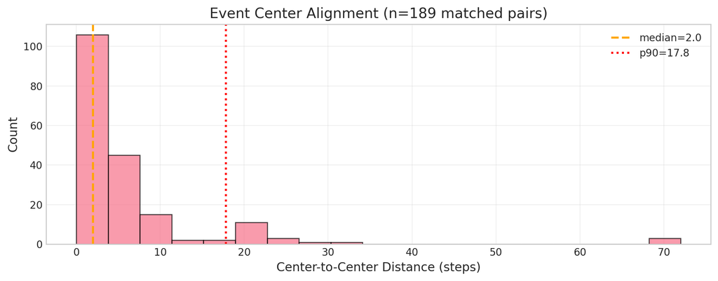

```
-> Median offset is small - events are well-aligned despite low IoU.
   The IoU ceiling is likely due to SHORT WINDOWS, not misalignment.
```

```python
# Center-Distance Diagnostics: How far apart are matched event centers?
# This tests the "1-2 tick offset" hypothesis

def compute_center_distances(overlap_result):
    """Extract center-to-center step distances from matched pairs."""
    matches = overlap_result.get("matches", [])
    if not matches:
        return []
    return [abs(m["step_a"] - m["step_b"]) for m in matches]

# Collect all center distances across pairs
all_center_distances = []
for pair_key, result in pairwise_overlap_results.items():
    # Use tau=0 to get all matches regardless of IoU
    full_overlap = compute_window_overlap_invariance(
        [runs[int(pair_key.split('-')[0])-1], runs[int(pair_key.split('-')[1])-1]],
        iou_threshold=0.0,
        compute_all_ious=True
    )
    distances = compute_center_distances(full_overlap)
    all_center_distances.extend(distances)

if all_center_distances:
    distances_arr = np.array(all_center_distances)

    print("Center-Distance Statistics (matched pairs at tau=0):")
    print(f"  - n pairs: {len(distances_arr)}")
    print(f"  - Mean |centerA - centerB|: {np.mean(distances_arr):.1f} steps")
    print(f"  - Median: {np.median(distances_arr):.1f} steps")
    print(f"  - Std: {np.std(distances_arr):.1f} steps")
    print(f"  - p90: {np.percentile(distances_arr, 90):.1f} steps")
    print(f"  - p95: {np.percentile(distances_arr, 95):.1f} steps")
    print(f"  - Max: {np.max(distances_arr):.1f} steps")

    # Plot histogram
    fig, ax = plt.subplots(figsize=(10, 4))
    ax.hist(distances_arr, bins=min(30, len(set(distances_arr))), edgecolor='black', alpha=0.7)
    ax.axvline(np.median(distances_arr), color='orange', linestyle='--', linewidth=2, label=f'median={np.median(distances_arr):.1f}')
    ax.axvline(np.percentile(distances_arr, 90), color='red', linestyle=':', linewidth=2, label=f'p90={np.percentile(distances_arr, 90):.1f}')
    ax.set_xlabel("Center-to-Center Distance (steps)", fontsize=12)
    ax.set_ylabel("Count", fontsize=12)
    ax.set_title(f"Event Center Alignment (n={len(distances_arr)} matched pairs)", fontsize=14)
    ax.legend()
    ax.grid(True, alpha=0.3)
    plt.tight_layout()
    plt.show()

    # Interpret
    if np.median(distances_arr) <= 5:
        print("\n-> Median offset is small - events are well-aligned despite low IoU.")
        print("   The IoU ceiling is likely due to SHORT WINDOWS, not misalignment.")
    else:
        print("\n-> Median offset is larger - events may genuinely differ in timing.")
else:
    print("No matched pairs found.")
```

### 4.2 IoU Dilation Experiment

What happens if we expand event windows by ±1 tick before computing IoU? This models the hypothesis that events are "off by 1-2 grid points" due to discretization.

```python
# IoU Dilation Experiment: Use built-in window_dilation parameter
# This tests whether the IoU ceiling is due to discretization/grid alignment

if len(runs) >= 2:
    print("IoU Dilation Experiment (first pair):\n")
    print("Using built-in window_dilation parameter to expand comparison windows\n")

    # Baseline (no dilation)
    baseline = compute_window_overlap_invariance(
        [runs[0], runs[1]],
        iou_threshold=IOU_THRESHOLD,
        compute_all_ious=True,
        window_dilation=0
    )

    # Dilate by 1 step (expands windows by ±1 step)
    dilated_1 = compute_window_overlap_invariance(
        [runs[0], runs[1]],
        iou_threshold=IOU_THRESHOLD,
        compute_all_ious=True,
        window_dilation=1
    )

    # Dilate by 2 steps
    dilated_2 = compute_window_overlap_invariance(
        [runs[0], runs[1]],
        iou_threshold=IOU_THRESHOLD,
        compute_all_ious=True,
        window_dilation=2
    )

    # Dilate by cadence (one full tick)
    cadence = int(np.median(np.diff(sorted(runs[0].geometry_df["step"].unique()))))
    dilated_cadence = compute_window_overlap_invariance(
        [runs[0], runs[1]],
        iou_threshold=IOU_THRESHOLD,
        compute_all_ious=True,
        window_dilation=cadence
    )

    print(f"{'Metric':<20} {'Baseline':<12} {'±1 step':<12} {'±2 steps':<12} {'±{0} (cadence)':<12}".format(cadence))
    print("-" * 68)
    print(f"{'Jaccard':<20} {baseline['jaccard_overlap']:.1%}{'':>5} {dilated_1['jaccard_overlap']:.1%}{'':>5} {dilated_2['jaccard_overlap']:.1%}{'':>5} {dilated_cadence['jaccard_overlap']:.1%}")
    print(f"{'Matched pairs':<20} {baseline['n_matched_pairs']:<12} {dilated_1['n_matched_pairs']:<12} {dilated_2['n_matched_pairs']:<12} {dilated_cadence['n_matched_pairs']}")
    print(f"{'Mean IoU':<20} {baseline['mean_iou']:.3f}{'':>5} {dilated_1['mean_iou']:.3f}{'':>5} {dilated_2['mean_iou']:.3f}{'':>5} {dilated_cadence['mean_iou']:.3f}")

    # Get max IoU from each
    max_baseline = baseline.get('iou_distribution', {}).get('max', 0)
    max_d1 = dilated_1.get('iou_distribution', {}).get('max', 0)
    max_d2 = dilated_2.get('iou_distribution', {}).get('max', 0)
    max_dc = dilated_cadence.get('iou_distribution', {}).get('max', 0)
    print(f"{'Max IoU':<20} {max_baseline:.3f}{'':>5} {max_d1:.3f}{'':>5} {max_d2:.3f}{'':>5} {max_dc:.3f}")

    # Interpret
    jaccard_gain = dilated_cadence['jaccard_overlap'] - baseline['jaccard_overlap']
    if jaccard_gain > 0.05:
        print(f"\n-> Dilation by ±{cadence} steps (1 tick) improves Jaccard by {jaccard_gain:.1%}")
        print("   This confirms the IoU ceiling is due to discretization, not misalignment.")
    elif jaccard_gain > 0.02:
        print(f"\n-> Dilation has moderate effect (+{jaccard_gain:.1%}) - some discretization impact.")
    else:
        print(f"\n-> Dilation has minimal effect ({jaccard_gain:+.1%}) - windows are already well-aligned.")
```

```
IoU Dilation Experiment (first pair):

Using built-in window_dilation parameter to expand comparison windows

Metric               Baseline     ±1 step      ±2 steps     ±2 (cadence)
--------------------------------------------------------------------
Jaccard              28.6%      33.2%      33.2%      33.2%
Matched pairs        166          186          186          186
Mean IoU             0.400      0.432      0.479      0.479
Max IoU              0.466      0.500      0.550      0.550

-> Dilation has moderate effect (+4.6%) - some discretization impact.
```

### 4.2.1 Neighbor Coverage Analysis

The "middle layer" metric: measures whether events have neighbors within suppression radius scale.

**Key distinction:**

- **Neighbor Coverage** answers: "Do both seeds show activity in the same neighborhoods?"
- **Peak/IoU Jaccard** answers: "Do they select the same discrete winners?"

**Definition:**

- **Signature (matching key)**: (layer, metric, event_type)
- **Neighbor condition**: ∃ event in other run with |Δstep| ≤ radius_steps
- **Formula**: (A_has_neighbor + B_has_neighbor) / (|A| + |B|)

**This is NOT a true Jaccard** (no set intersection/union). It's a symmetric coverage score.

**Interpretation:**

- High coverage + low Event Jaccard = "stable energy landscape, unstable argmax" (regions are consistent, winner selection jitters)
- Low coverage = genuinely different event locations

```python
# Neighbor Coverage Analysis - measures bidirectional neighbor presence at suppression radius scale
# This is the "middle layer" between trajectories and selected peaks

if len(runs) >= 2:
    print("Neighbor Coverage Analysis")
    print("=" * 50)
    print("Neighbor Coverage: 'Do both seeds show activity in the same neighborhoods?'")
    print("Peak/IoU Jaccard: 'Do they select the same discrete winners?'")
    print()
    print(f"Radius: ±{15} steps (= suppression_radius)")
    print("Winner = argmax by score (tiebreak: smallest step)")
    print()

    # Compute neighbor coverage for all pairs
    for pair_key in pairwise_overlap_results.keys():
        i, j = [int(x)-1 for x in pair_key.split('-')]
        nc_result = compute_neighbor_coverage([runs[i], runs[j]], radius_steps=15)

        seed_i = runs[i].meta.get('seed', '?')
        seed_j = runs[j].meta.get('seed', '?')

        print(f"Pair {pair_key} (seed {seed_i} vs {seed_j}):")
        print(f"  Neighbor Coverage (±15): {nc_result['neighbor_coverage']:.1%}")
        print(f"    A has neighbor: {nc_result['coverage_a']:.1%} ({nc_result['events_a_with_neighbor']}/{nc_result['total_events_a']})")
        print(f"    B has neighbor: {nc_result['coverage_b']:.1%} ({nc_result['events_b_with_neighbor']}/{nc_result['total_events_b']})")
        print(f"  Signatures with overlap: {nc_result['n_signatures_with_overlap']}")
        print(f"  Winner stability (exact match): {nc_result['winner_stability']:.1%}")
        print(f"  Winner close stability (±{nc_result['radius_steps']//2} steps): {nc_result['winner_close_stability']:.1%}")

        # Display NN distance stats
        nn_stats = nc_result.get('nn_distance_stats', {})
        if nn_stats:
            print(f"  Nearest-neighbor distance (A↔B):")
            print(f"    Median: {nn_stats['median']:.1f} steps")
            print(f"    p90: {nn_stats['p90']:.1f} steps, p95: {nn_stats['p95']:.1f} steps")
            print(f"    Within radius (±{nc_result['radius_steps']}): {nn_stats['within_radius']:.1%}")
            print(f"    Within half-radius (±{nc_result['radius_steps']//2}): {nn_stats['within_half_radius']:.1%}")

        print(f"  → {nc_result['interpretation']}")
        print()

    # Compare to event-level Jaccard
    if len(pairwise_overlap_results) > 0:
        first_pair_key = list(pairwise_overlap_results.keys())[0]
        event_jaccard = pairwise_overlap_results[first_pair_key]['jaccard_overlap']
        nc_result = compute_neighbor_coverage([runs[0], runs[1]], radius_steps=15)
        neighbor_coverage = nc_result['neighbor_coverage']

        print("=" * 50)
        print("COMPARISON (first pair):")
        print(f"  Event Jaccard (IoU≥{IOU_THRESHOLD}): {event_jaccard:.1%}")
        print(f"  Neighbor Coverage (±15): {neighbor_coverage:.1%}")

        if neighbor_coverage > event_jaccard * 1.5:
            print()
            print("  → Neighbor Coverage >> Event Jaccard")
            print("    Both seeds detect events in the same NEIGHBORHOODS,")
            print("    but pick different WINNERS within those neighborhoods.")
            print("    This is 'stable energy landscape / unstable argmax'.")
```

```
Neighbor Coverage Analysis
==================================================
Neighbor Coverage: 'Do both seeds show activity in the same neighborhoods?'
Peak/IoU Jaccard: 'Do they select the same discrete winners?'

Radius: ±15 steps (= suppression_radius)
Winner = argmax by score (tiebreak: smallest step)

Pair 1-2 (seed 37 vs 42):
  Neighbor Coverage (±15): 51.1%
    A has neighbor: 50.5% (207/410)
    B has neighbor: 51.8% (174/336)
  Signatures with overlap: 75
  Winner stability (exact match): 0.0%
  Winner close stability (±7 steps): 88.0%
  Nearest-neighbor distance (A↔B):
    Median: 13.0 steps
    p90: 78.0 steps, p95: 96.0 steps
    Within radius (±15): 51.1%
    Within half-radius (±7): 40.8%
  → Moderate neighbor coverage with good winner alignment: about half of events find neighbors, and when they do, peaks align well.

==================================================
COMPARISON (first pair):
  Event Jaccard (IoU≥0.2): 28.6%
  Neighbor Coverage (±15): 51.1%

  → Neighbor Coverage >> Event Jaccard
    Both seeds detect events in the same NEIGHBORHOODS,
    but pick different WINNERS within those neighborhoods.
    This is 'stable energy landscape / unstable argmax'.
```

### 4.3 Candidate vs Selected Overlap

Are events being filtered out by suppression, or do they genuinely differ? Compare pre-suppression (candidate-level) vs post-suppression (selected-level) overlap.

```python
# Candidate vs Selected Overlap Analysis
# Uses detection_summary to compare raw candidates vs selected events

from squiggle_core import paths as core_paths

def load_detection_summary(run):
    """Load detection summary for a run (contains candidate counts per series)."""
    summary_path = core_paths.detection_summary_path(run.run_id, run.analysis_id)
    if summary_path.exists():
        return pd.read_parquet(summary_path)
    return None

# Load detection summaries
detection_summaries = [load_detection_summary(run) for run in runs]
has_summaries = all(ds is not None for ds in detection_summaries)

if has_summaries and len(runs) >= 2:
    print("Candidate vs Selected Overlap Analysis:\n")

    # Display retention stats side by side
    for i, (run, ds) in enumerate(zip(runs, detection_summaries)):
        seed = run.meta.get('seed', '?')
        n_candidates = ds["n_candidates_raw"].sum()
        n_selected = ds["n_selected_final"].sum()
        n_suppressed = ds["n_skipped_suppression"].sum()
        n_topk = ds["n_skipped_topk"].sum()

        print(f"Run {i+1} (seed {seed}):")
        print(f"  - Candidates (raw): {n_candidates}")
        print(f"  - Selected (final): {n_selected}")
        print(f"  - Skipped (suppression): {n_suppressed}")
        print(f"  - Skipped (top-k): {n_topk}")
        print(f"  - Retention: {n_selected/max(n_candidates,1):.1%}")
        print()

    # Compute what fraction of candidates are shared vs what fraction of selected are shared
    # This requires comparing candidate-level events, which we can approximate from detection_summary

    # For now, show the retention gap interpretation
    r1, r2 = runs[0].retention, runs[1].retention
    if r1 and r2:
        print("Interpretation:")

        # Suppression comparison
        supp_rate_1 = (r1.suppression_pre + r1.suppression_post) / max(r1.n_candidates, 1)
        supp_rate_2 = (r2.suppression_pre + r2.suppression_post) / max(r2.n_candidates, 1)

        print(f"  - Suppression rate: {supp_rate_1:.1%} (run 1) vs {supp_rate_2:.1%} (run 2)")

        if abs(supp_rate_1 - supp_rate_2) > 0.1:
            print("  -> Suppression rates differ significantly - selection instability likely.")
        else:
            print("  -> Suppression rates are similar - events filtered consistently.")

        # Check if candidate density explains differences
        density_ratio = r1.mean_candidates_post_per_series / max(r2.mean_candidates_post_per_series, 0.1)
        if abs(density_ratio - 1.0) > 0.3:
            print(f"  -> Candidate density differs {density_ratio:.1f}x - more candidates = more collisions.")
else:
    print("Detection summaries not available for candidate-level analysis.")
    print("Re-run event detection with recent squiggle_analysis to generate detection_summary.parquet.")
```

```
Candidate vs Selected Overlap Analysis:

Run 1 (seed 37):
  - Candidates (raw): 2219
  - Selected (final): 327
  - Skipped (suppression): 229
  - Skipped (top-k): 1131
  - Retention: 14.7%

Run 2 (seed 42):
  - Candidates (raw): 1394
  - Selected (final): 312
  - Skipped (suppression): 169
  - Skipped (top-k): 644
  - Retention: 22.4%

Interpretation:
  - Suppression rate: 10.3% (run 1) vs 12.1% (run 2)
  -> Suppression rates are similar - events filtered consistently.
  -> Candidate density differs 1.6x - more candidates = more collisions.
```

## 5. IoU Distribution Histogram

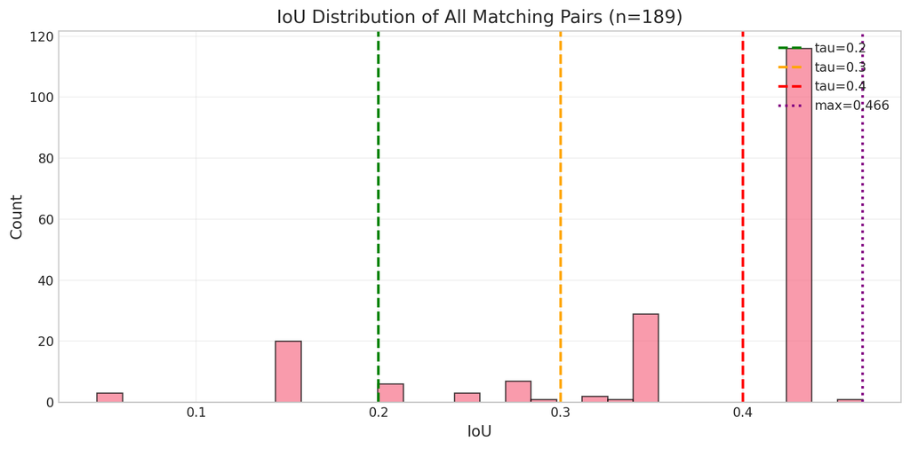

```
IoU Statistics:
  - Count: 189
  - Max: 0.466
  - Mean: 0.368
  - Median: 0.438
  - Std: 0.106
```

```python
# Collect all IoUs from all pairwise comparisons
all_match_ious = []
for pair_key, result in pairwise_overlap_results.items():
    full_overlap = compute_window_overlap_invariance(
        [runs[int(pair_key.split('-')[0])-1], runs[int(pair_key.split('-')[1])-1]],
        iou_threshold=0.0,
        compute_all_ious=True
    )
    pair_ious = [m["iou"] for m in full_overlap.get("matches", [])]
    all_match_ious.extend(pair_ious)

if all_match_ious:
    fig, ax = plt.subplots(figsize=(10, 5))

    ax.hist(all_match_ious, bins=30, edgecolor='black', alpha=0.7)

    # Add vertical lines for key thresholds
    for tau, color in [(0.2, 'green'), (0.3, 'orange'), (0.4, 'red')]:
        ax.axvline(tau, color=color, linestyle='--', linewidth=2, label=f'tau={tau}')

    # Add max IoU line
    max_iou = max(all_match_ious)
    ax.axvline(max_iou, color='purple', linestyle=':', linewidth=2, label=f'max={max_iou:.3f}')

    ax.set_xlabel("IoU", fontsize=12)
    ax.set_ylabel("Count", fontsize=12)
    title_suffix = f" (aggregated across {len(pairwise_overlap_results)} pairs)" if len(runs) > 2 else ""
    ax.set_title(f"IoU Distribution of All Matching Pairs (n={len(all_match_ious)}){title_suffix}", fontsize=14)
    ax.legend(loc="upper right")
    ax.grid(True, alpha=0.3)

    plt.tight_layout()
    plt.show()

    print(f"IoU Statistics:")
    print(f"  - Count: {len(all_match_ious)}")
    print(f"  - Max: {max(all_match_ious):.3f}")
    print(f"  - Mean: {np.mean(all_match_ious):.3f}")
    print(f"  - Median: {np.median(all_match_ious):.3f}")
    print(f"  - Std: {np.std(all_match_ious):.3f}")
```

```python
# LLM Analysis: IoU Distribution
if ENABLE_LLM_ANALYSIS and all_match_ious:
    iou_dist_analysis = analyze_iou_distribution(
        iou_values=all_match_ious,
        thresholds=[0.2, 0.3, 0.4],
        backend=LLM_BACKEND,
        model=LLM_MODEL,
    )
    display_analysis(iou_dist_analysis, "IoU Distribution")

    # Store for overall synthesis
    SECTION_ANALYSES.append({
        "section_name": "IoU Distribution",
        "interpretation": iou_dist_analysis.interpretation,
        "observations": iou_dist_analysis.key_observations,
    })
```

🤖 LLM Analysis: IoU Distribution

**Key Observations:**

- There is a noticeable drop in the fraction of matches exceeding higher thresholds, with only 61.9% surpassing 0.4, indicating distinct tiers of matching quality.

- The maximum IoU of 0.466 suggests that while some matches are well-aligned, there is still room for improvement in achieving higher alignment limits.

**Questions Raised:**

- What factors contribute to the observed drop in matches exceeding the 0.4 threshold?

- How do these IoU values compare to benchmarks in similar tasks or datasets?

## 6. Trajectory Comparison

```python
# Compute trajectory correlation (already supports N runs)
layers_to_plot = [0, 6, 12, 18, 23]
corr_matrix = compute_trajectory_correlation(runs, metric="effective_rank", layers=layers_to_plot)

print("Trajectory Correlation Matrix (effective_rank):")
display(corr_matrix)

# Compute mean off-diagonal correlation
mask = ~np.eye(len(corr_matrix), dtype=bool)
off_diag = corr_matrix.values[mask]
mean_corr = np.nanmean(off_diag)
print(f"\nMean pairwise correlation: {mean_corr:.3f}")
```

```
Trajectory Correlation Matrix (effective_rank):
```

|  | 20260129_210111_research_test_a1_s37 | 20260129_145609_research_test_a1_s42 |
| --- | --- | --- |
| 20260129_210111_research_test_a1_s37 | 1.000000 | 0.913997 |
| 20260129_145609_research_test_a1_s42 | 0.913997 | 1.000000 |

```
Mean pairwise correlation: 0.914
```

```python
def plot_trajectory_comparison(runs, metric, layers, figsize=None):
    """Plot trajectory comparison for a metric across layers."""
    n_layers = len(layers)
    if figsize is None:
        figsize = (14, 2 * n_layers)
    fig, axes = plt.subplots(n_layers, 1, figsize=figsize, sharex=True)
    if n_layers == 1:
        axes = [axes]

    colors = plt.cm.tab10.colors

    for i, layer in enumerate(layers):
        ax = axes[i]

        for j, run in enumerate(runs):
            traj = extract_metric_trajectories(run.geometry_df, layers=[layer], metric=metric)
            if not traj.empty:
                seed = run.meta.get('seed', f'run{j+1}')
                ax.plot(
                    traj["step"],
                    traj["value"],
                    color=colors[j % len(colors)],
                    linewidth=1.5,
                    alpha=0.8,
                    label=f"seed={seed}"
                )

        ax.set_ylabel(f"Layer {layer}", fontsize=10)
        ax.grid(True, alpha=0.3)
        if i == 0:
            ax.legend(loc="upper right", fontsize=9, ncol=min(len(runs), 4))
            ax.set_title(f"{metric} Trajectories ({len(runs)} runs)", fontsize=14)

    axes[-1].set_xlabel("Step", fontsize=12)
    plt.tight_layout()
    return fig, axes
```

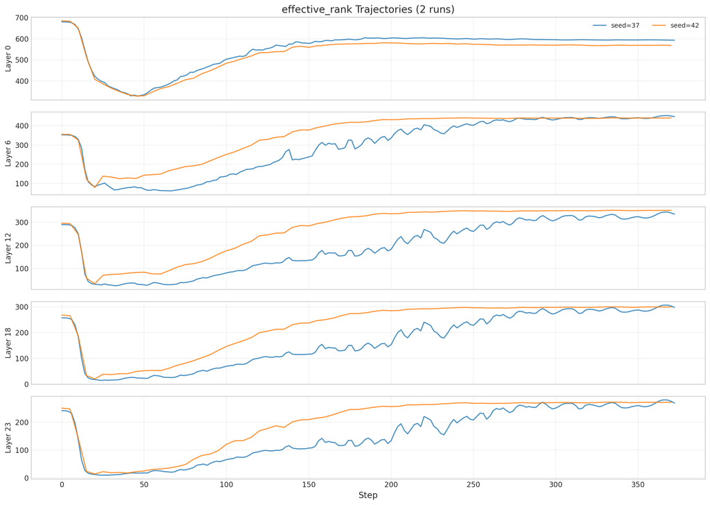

```python
# Plot effective_rank trajectories
fig, axes = plot_trajectory_comparison(runs, "effective_rank", layers_to_plot)
plt.show()
```

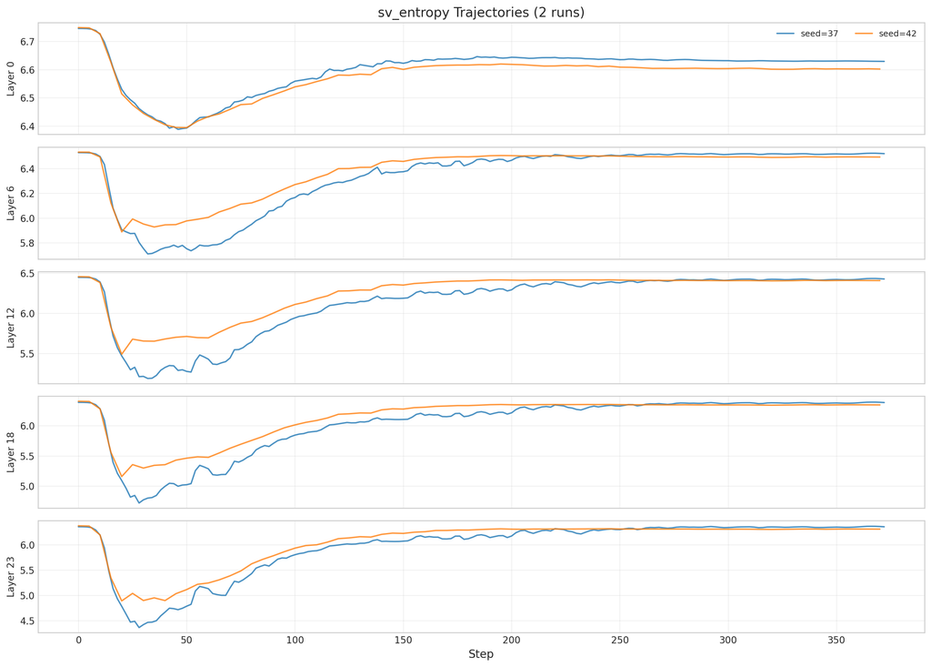

```python
# Plot sv_entropy trajectories
fig, axes = plot_trajectory_comparison(runs, "sv_entropy", layers_to_plot)
plt.show()
```

```python
# LLM Analysis: Trajectory Comparison
if ENABLE_LLM_ANALYSIS:
    traj_analysis = analyze_trajectory_comparison(
        correlation_matrix=corr_matrix,
        metric="effective_rank",
        layers=layers_to_plot,
        backend=LLM_BACKEND,
        model=LLM_MODEL,
    )
    display_analysis(traj_analysis, "Trajectory Comparison")

    # Store for overall synthesis
    SECTION_ANALYSES.append({
        "section_name": "Trajectory Comparison",
        "interpretation": traj_analysis.interpretation,
        "observations": traj_analysis.key_observations,
    })
```

🤖 LLM Analysis: Trajectory Comparison

**Interpretation:** The trajectory correlation between the two runs is exceptionally high at 0.914, indicating that the learning dynamics of effective_rank are consistent across the runs. This suggests that the underlying signal driving the changes in effective_rank is robust, although the high correlation paired with potential low event overlap may imply sensitivity in event selection during the analysis.

**Key Observations:**

- Both runs exhibit strong alignment in the effective_rank trajectory, with a mean cross-run correlation of 0.914.

- The high correlation suggests that the learning dynamics are stable and reproducible across different random seeds.

- The potential for low event overlap indicates that while the signal is consistent, the specific events detected may vary, pointing to sensitivity in the event detection process.

**Questions Raised:**

- What factors contributed to the low event overlap despite high trajectory correlation?

- How might adjusting the detection parameters impact the event selection and overall analysis?

## 7. Composite Event Analysis

```python
# Compute composite invariance for all pairs
pairwise_composite_results = {}

for i, j in run_pairs:
    pair_key = f"{i+1}-{j+1}"
    pair_runs = [runs[i], runs[j]]
    comp_inv = compute_composite_invariance(pair_runs, iou_threshold=0.3)
    pairwise_composite_results[pair_key] = comp_inv

# Display results
print("Composite Invariance (pairwise):\n")
for pair_key, comp_inv in pairwise_composite_results.items():
    i, j = [int(x)-1 for x in pair_key.split('-')]
    seed_i = runs[i].meta.get('seed', '?')
    seed_j = runs[j].meta.get('seed', '?')
    print(f"Pair {pair_key} (seed {seed_i} vs {seed_j}):")
    print(f"  - Composites: {comp_inv['n_composites_a']} / {comp_inv['n_composites_b']}")
    print(f"  - Matched: {comp_inv['n_matched']}")
    print(f"  - Jaccard: {comp_inv['jaccard']:.1%}")
    if comp_inv.get('strength_correlation'):
        print(f"  - Strength correlation: {comp_inv['strength_correlation']:.2f}")
    print()

# Use first pair for backward compatibility
comp_inv = list(pairwise_composite_results.values())[0] if pairwise_composite_results else {}
```

```
Composite Invariance (pairwise):

Pair 1-2 (seed 37 vs 42):
  - Composites: 83 / 24
  - Matched: 17
  - Jaccard: 18.9%
  - Strength correlation: 0.68
```

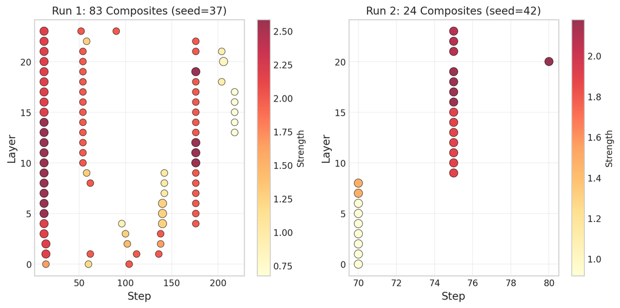

```python
# Plot composite events for all runs
n_runs = len(runs)
n_cols = min(n_runs, 3)
n_rows = (n_runs + n_cols - 1) // n_cols
fig, axes = plt.subplots(n_rows, n_cols, figsize=(5 * n_cols, 5 * n_rows), squeeze=False)

for idx, run in enumerate(runs):
    row, col = idx // n_cols, idx % n_cols
    ax = axes[row, col]

    comp_df = run.events_df[run.events_df["event_type"] == "change_point_composite"]
    seed = run.meta.get('seed', '?')

    if not comp_df.empty and "composite_strength" in comp_df.columns:
        scatter = ax.scatter(
            comp_df["step"],
            comp_df["layer"],
            c=comp_df["composite_strength"],
            s=comp_df.get("composite_n_metrics", 3) * 30,
            cmap="YlOrRd",
            alpha=0.8,
            edgecolors='black',
            linewidths=0.5
        )
        plt.colorbar(scatter, ax=ax, label="Strength")
    else:
        ax.scatter(comp_df["step"], comp_df["layer"], s=50, alpha=0.7)

    ax.set_xlabel("Step", fontsize=12)
    ax.set_ylabel("Layer", fontsize=12)
    ax.set_title(f"Run {idx+1}: {len(comp_df)} Composites (seed={seed})", fontsize=12)
    ax.grid(True, alpha=0.3)

# Hide unused subplots
for idx in range(n_runs, n_rows * n_cols):
    row, col = idx // n_cols, idx % n_cols
    axes[row, col].set_visible(False)

plt.tight_layout()
plt.show()
```

```python
# LLM Analysis: Composite Events
if ENABLE_LLM_ANALYSIS:
    # Get composite counts for all runs
    composite_counts = [
        len(run.events_df[run.events_df["event_type"] == "change_point_composite"])
        for run in runs
    ]

    # Aggregate composite invariance across pairs
    all_comp_jaccards = [r['jaccard'] for r in pairwise_composite_results.values()]

    comp_analysis = analyze_composite_events(
        composite_invariance={
            **comp_inv,  # First pair details
            'n_pairs': len(pairwise_composite_results),
            'mean_jaccard_across_pairs': np.mean(all_comp_jaccards) if all_comp_jaccards else 0,
        },
        run_a_composites=composite_counts[0],
        run_b_composites=composite_counts[1] if len(composite_counts) > 1 else 0,
        backend=LLM_BACKEND,
        model=LLM_MODEL,
    )
    display_analysis(comp_analysis, "Composite Events")

    # Store for overall synthesis
    SECTION_ANALYSES.append({
        "section_name": "Composite Events",
        "interpretation": comp_analysis.interpretation,
        "observations": comp_analysis.key_observations,
    })
```

🤖 LLM Analysis: Composite Events

**Interpretation:** The composite event comparison reveals a significant disparity in the number of detected composites between the two runs, with Run A exhibiting a higher total but lower coverage than Run B. The Jaccard similarity of 18.9% indicates weak invariance among the composite events, suggesting that many composites are unique to each run. The strength correlation of 0.68 indicates a moderate relationship in the occurrence of composite events across runs, hinting at some underlying shared dynamics despite the low Jaccard similarity.

**Key Observations:**

- Run A has 83 composite events, but only 20.5% coverage, indicating many unique events.

- Run B has a much higher coverage at 70.8%, despite having only 24 composites, suggesting a more consistent event structure.

- The strength correlation of 0.68 indicates a moderate level of shared dynamics between the runs, despite the low Jaccard similarity.

**Questions Raised:**

- What factors contributed to the high number of unique composites in Run A compared to Run B?

- How do the individual event dynamics compare to the composite events in terms of stability and invariance?

## 8. Event Phase Distribution

```python
# Analyze phases for all runs
phase_results = [analyze_event_phases(run) for run in runs]

print("Phase Analysis:\n")
for i, (run, phase_data) in enumerate(zip(runs, phase_results)):
    seed = run.meta.get('seed', '?')
    print(f"Run {i+1} (seed {seed}): {phase_data['phase_counts']}")
```

```
Phase Analysis:

Run 1 (seed 37): {'shaping': 240, 'transition': 170}
Run 2 (seed 42): {'shaping': 239, 'transition': 97}
```

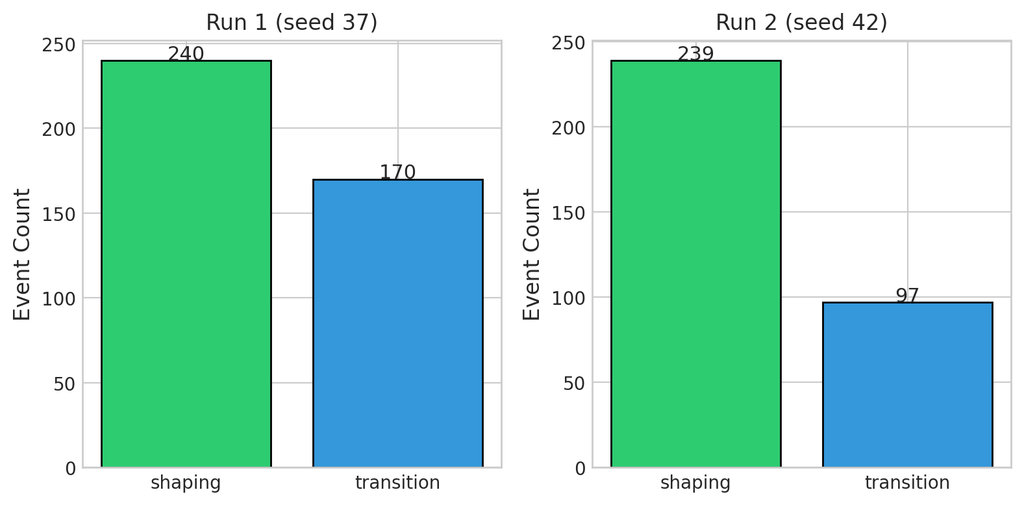

```python
# Plot phase distribution for all runs
n_runs = len(runs)
fig, axes = plt.subplots(1, n_runs, figsize=(4 * n_runs, 4), squeeze=False)

for idx, (run, phase_data) in enumerate(zip(runs, phase_results)):
    ax = axes[0, idx]
    phases = phase_data["phase_counts"]
    seed = run.meta.get('seed', '?')

    if phases:
        labels = list(phases.keys())
        values = list(phases.values())
        colors = ['#2ecc71', '#3498db', '#9b59b6']  # shaping, transition, locking

        ax.bar(labels, values, color=colors[:len(labels)], edgecolor='black')
        ax.set_ylabel("Event Count", fontsize=12)
        ax.set_title(f"Run {idx+1} (seed {seed})", fontsize=12)

        # Add value labels
        for i, v in enumerate(values):
            ax.text(i, v + 0.5, str(v), ha='center', fontsize=11)

plt.tight_layout()
plt.show()
```

```python
# LLM Analysis: Phase Distribution
if ENABLE_LLM_ANALYSIS:
    # Use first two runs for the existing function, but could extend to N runs
    phase_analysis = analyze_phase_distribution(
        phase_a=phase_results[0],
        phase_b=phase_results[1] if len(phase_results) > 1 else {"phase_counts": {}},
        backend=LLM_BACKEND,
        model=LLM_MODEL,
    )
    display_analysis(phase_analysis, "Phase Distribution")

    # Store for overall synthesis
    SECTION_ANALYSES.append({
        "section_name": "Phase Distribution",
        "interpretation": phase_analysis.interpretation,
        "observations": phase_analysis.key_observations,
    })
```

🤖 LLM Analysis: Phase Distribution

**Interpretation:** Both runs exhibit a similar number of events in the shaping phase, with Run A having 240 and Run B having 239. However, Run A shows a significantly higher concentration of events in the transition phase (170) compared to Run B (97), indicating that Run A experienced more dynamic learning during this critical phase. The asymmetry in transition phase events suggests that Run A may have engaged in more complex learning dynamics, potentially leading to richer representations.

**Key Observations:**

- Run A has a higher concentration of events in the transition phase compared to Run B, indicating more active learning.

- Both runs have nearly identical shaping phase events, suggesting consistent early learning dynamics.

- The disparity in transition phase events may reflect differences in model capacity or learning strategies employed in each run.

**Questions Raised:**

- What factors contributed to the higher number of transition phase events in Run A?

- Could the differences in transition phase events impact the final performance of the models?

## 9. Retention Analysis

```python
# Display retention metrics for all runs
runs_with_retention = [run for run in runs if run.retention]

if runs_with_retention:
    retention_data = {
        "Metric": ["Candidates", "Selected", "Retention Rate", "Pre-Warmup Ret.", "Post-Warmup Ret.", "Cand/Series (post)"],
    }

    for run in runs_with_retention:
        seed = run.meta.get('seed', '?')
        col_name = f"Run (s{seed})"
        retention_data[col_name] = [
            run.retention.n_candidates,
            run.retention.n_selected,
            f"{run.retention.retention_rate:.1%}",
            f"{run.retention.pre_retention_rate:.1%}",
            f"{run.retention.post_retention_rate:.1%}",
            f"{run.retention.mean_candidates_post_per_series:.1f}",
        ]

    retention_df = pd.DataFrame(retention_data)
    display(retention_df)

    # Compute density ratios between pairs
    if len(runs_with_retention) >= 2:
        print("\nDensity Ratios (pairwise):")
        for i in range(len(runs_with_retention)):
            for j in range(i + 1, len(runs_with_retention)):
                r1, r2 = runs_with_retention[i].retention, runs_with_retention[j].retention
                ratio = r1.mean_candidates_post_per_series / max(r2.mean_candidates_post_per_series, 0.1)
                s1 = runs_with_retention[i].meta.get('seed', '?')
                s2 = runs_with_retention[j].meta.get('seed', '?')
                print(f"  seed {s1} / seed {s2}: {ratio:.2f}x")
else:
    print("Retention data not available for any runs.")
```

|  | Metric | Run (s37) | Run (s42) |
| --- | --- | --- | --- |
| 0 | Candidates | 2219 | 1394 |
| 1 | Selected | 327 | 312 |
| 2 | Retention Rate | 14.7% | 22.4% |
| 3 | Pre-Warmup Ret. | 11.8% | 21.1% |
| 4 | Post-Warmup Ret. | 15.8% | 22.8% |
| 5 | Cand/Series (post) | 22.8 | 14.6 |

```
Density Ratios (pairwise):
  seed 37 / seed 42: 1.56x
```

```python
# LLM Analysis: Retention
if ENABLE_LLM_ANALYSIS and len(runs_with_retention) >= 2:
    retention_analysis = analyze_retention(
        retention_a={
            "n_candidates": runs_with_retention[0].retention.n_candidates,
            "n_selected": runs_with_retention[0].retention.n_selected,
            "retention_rate": f"{runs_with_retention[0].retention.retention_rate:.1%}",
            "pre_retention_rate": f"{runs_with_retention[0].retention.pre_retention_rate:.1%}",
            "post_retention_rate": f"{runs_with_retention[0].retention.post_retention_rate:.1%}",
            "mean_candidates_post_per_series": f"{runs_with_retention[0].retention.mean_candidates_post_per_series:.1f}",
        },
        retention_b={
            "n_candidates": runs_with_retention[1].retention.n_candidates,
            "n_selected": runs_with_retention[1].retention.n_selected,
            "retention_rate": f"{runs_with_retention[1].retention.retention_rate:.1%}",
            "pre_retention_rate": f"{runs_with_retention[1].retention.pre_retention_rate:.1%}",
            "post_retention_rate": f"{runs_with_retention[1].retention.post_retention_rate:.1%}",
            "mean_candidates_post_per_series": f"{runs_with_retention[1].retention.mean_candidates_post_per_series:.1f}",
        },
        backend=LLM_BACKEND,
        model=LLM_MODEL,
    )
    display_analysis(retention_analysis, "Retention Metrics")

    # Store for overall synthesis
    SECTION_ANALYSES.append({
        "section_name": "Retention Metrics",
        "interpretation": retention_analysis.interpretation,
        "observations": retention_analysis.key_observations,
    })
```

🤖 LLM Analysis: Retention Metrics

**Interpretation:** Run B exhibits a higher overall retention rate (22.4%) compared to Run A (14.7%), indicating a stronger signal intensity in Run B. The candidate density in Run A is higher (22.8 candidates per series) than in Run B (14.6), suggesting that the greater number of candidates in Run A may contribute to its lower retention rate, as more candidates could lead to increased noise and less meaningful events.

**Key Observations:**

- Run A has a significantly higher number of candidates (2219) compared to Run B (1394), but Run B has a higher retention rate.

- Pre-warmup retention rates are notably higher in Run B (21.1%) than in Run A (11.8%), indicating that Run B had more informative early events.

**Questions Raised:**

- What factors contributed to the higher candidate density in Run A, and how might they have influenced the retention rate?

- Are there specific events in Run B that are consistently retained across multiple seeds, indicating robustness in the learning dynamics?